# slides

The Computational Intractability of  
Not Worst Responding

FATA Seminar, University of Glasgow | 17 February 2026

| **Mete Şeref Ahunbay** | **Paul W. Goldberg** | **Edwin Lock** |
| --- | --- | --- |
| Oxford | Oxford | King’s College London |
| **Panayotis Mertikopoulos** | **Bary S. R. Pradelski** | **Bassel Tarbush** |
| CNRS | CNRS & Oxford | Oxford |

## Nash equilibrium

Imagine a **strategic interaction**: several people each making a decision that affects everyone.

A **Nash equilibrium** is a situation where **nobody would change their mind**, even after seeing what everyone else chose.

Each person is already doing the best they can, *given* what everyone else is doing.

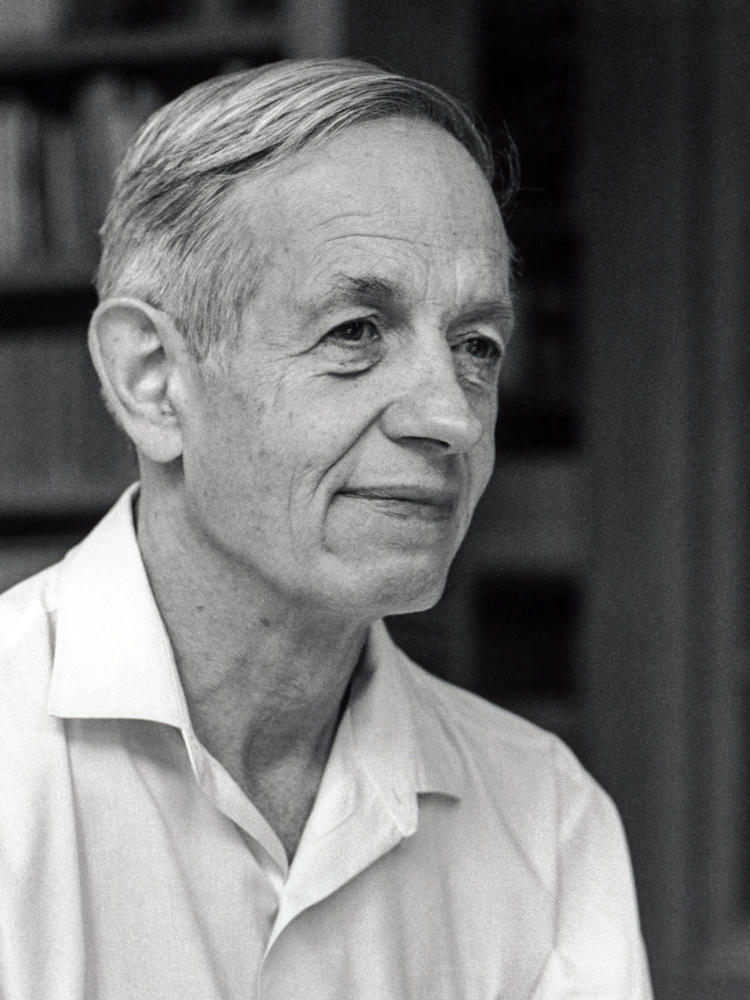

John Nash, 1928–2015

Foundational solution concept with applications in economics, political science, biology, computer science, $\ldots$

## Nash equilibrium is hard

But finding Nash equilibria in general games is **computationally intractable**.

What if we ask for much **less** than Nash?

What if each player merely needs to avoid their **worst** option?

This is arguably the weakest meaningful **individual rationality criterion**.

(Related, but not equivalent, to $\varepsilon$-approximate Nash Equilibria.)

> “Life could be worse.”

## Our results

We show that even this minimal requirement is **computationally equivalent** to Nash equilibrium.

In general (succinctly represented) games:

- **Deciding** whether a no-worst-response outcome exists is **NP-complete**
- **Finding** one is **NP-hard**
- **Counting** them is **#P-complete**

In potential games (where NE are guaranteed to exist):

- **Finding** a no-worst-response outcome is **PLS-complete**

**Tractability thresholds**: e.g., requiring only a fraction $\alpha < \frac{m-1}{m}$ of players to not worst-respond becomes tractable (**RP**).

## Why care about computational complexity?

- Solution concepts are meant to **predict** or **prescribe** behaviour
- If computing a solution is **intractable**, this undermines its plausibility
  - Players can’t find it
  - An analyst can’t recommend it
  - Learning dynamics can’t converge to it (efficiently)

> Computational complexity as a **minimal plausibility requirement** for solution concepts

> — Gilboa & Zemel (1989), Camara (2022)

# Background

## What is a game?

A **game** consists of:

- A set of **players** $N = \{1, \ldots, n\}$
- Each player $i$ has a set of **actions** $A_i = \{0, \ldots, m_i - 1\}$, and $A = A_1 \times \cdots \times A_n$.
- An **action profile** $a \in A$ specifies an action $a_i \in A_i$ for each player.
- We also write $a$ as $(a_i, a_{-i})$.
- Each player $i$ has a **payoff function** $u_i : A \to \mathbb{R}$.

> **Example:** Three friends choose where to eat: Pizza, Sushi, or Burger. Alice prefers eating with Bob; Bob prefers eating with Carol; Carol hates crowds.

We focus exclusively on **pure** actions (no randomisation).

## Best responses and Nash equilibrium

**Best response:** $a_i$ is a best response to $a_{-i}$ if

$$u_i(a_i, a_{-i}) \geq u_i(a_i', a_{-i}) \quad \forall \, a_i' \in A_i$$

No other action gives a higher payoff.

**Pure Nash equilibrium** (pNE): an action profile where **every** player plays a best response.

$\Rightarrow$ No one can **unilaterally** improve.

> **Example:** if Alice and Bob both pick Pizza, and Carol picks Sushi — is Bob best-responding? Given Carol’s choice, Bob prefers to switch to Sushi.

## Worst responses and not worst responding

**Worst response:** $a_i$ is a worst response to $a_{-i}$ if

$$u_i(a_i, a_{-i}) < u_i(a_i', a_{-i}) \quad \forall \, a_i' \in A_i \setminus \{a_i\}$$

Every other action is **strictly better**.

**No-worst-response (NWR) profile:** an action profile where **no** player plays a worst response.

> **Example:** if Carol’s payoffs are Pizza: 1, Sushi: 5, Burger: 3 — then Pizza is her **worst response**. Sushi and Burger are both “not worst”.

## Circuit games

Games can be **exponentially large** when written out as payoff tables.

To study complexity meaningfully, we need a compact representation.

A **circuit game** represents each player’s payoff function as a Boolean circuit:

- Input: the actions of all players (encoded in binary)
- Output: a rational number (encoded as quotient of two binary integers)

A standard model in computational game theory (Schoenebeck & Vadhan, 2006).

[figure not shown]

## Reductions: comparing hardness

A **reduction** from problem $f$ to problem $f'$:

1. **Push:** transform any instance of $f$ into an instance of $f'$.
2. **Solve** $f'$.
3. **Pull:** convert the solution to $f'$ back into an answer for $f$.

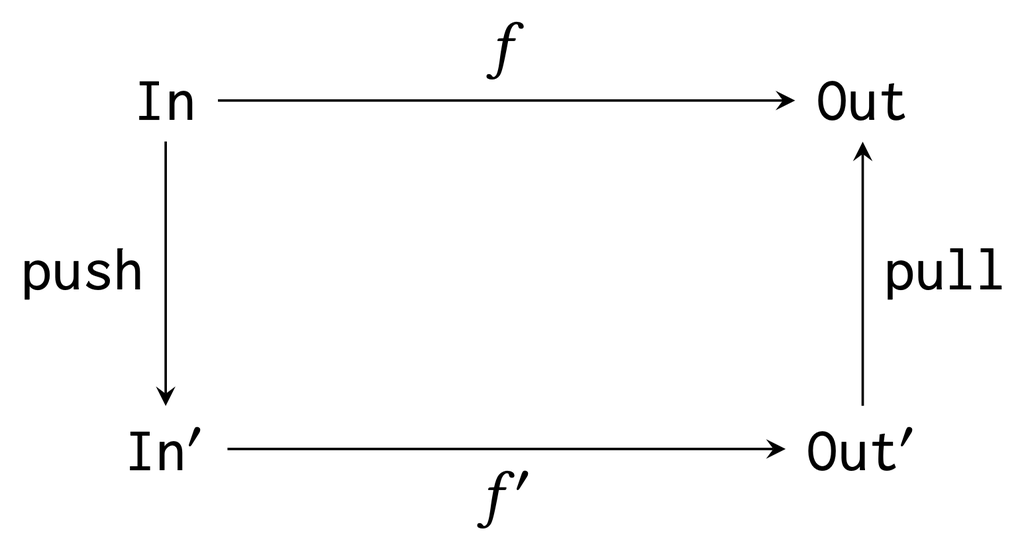

**Implications**

$\Rightarrow$ If $f$ efficiently reduces to $f'$, then $f'$ is **at least as hard** as $f$.

$\Rightarrow$ If we can reduce **both ways**, the problems are **equivalently hard**.

Reduction must be **polynomial-time** and **preserve relevant structure**: e.g., yes/no answers for decision problems, local optima for search problems (PLS), or solution counts for counting problems.

## Known results for pure Nash equilibrium

In circuit games:

| Problem | Complexity | Reference |
| --- | --- | --- |
| Does a pure NE exist? | **NP-complete** | Gottlob, Greco & Scarcello (2003) |
| Find a pure NE | **NP-hard** | Gottlob, Greco & Scarcello (2003) |
| Count pure NEs | **#P-complete** | Schoenebeck & Vadhan (2012) |
| Find a pure NE in potential games | **PLS-complete** | Fabrikant, Papadimitriou & Talwar (2004) |

Our question: does **relaxing “best response” to “not worst response”** make any of these easier?

(Almost) all our results concern circuit games with a **fixed number $m$ of actions** per player.

# General games

## Deciding existence of NWR profiles

**NP** is the class of decision problems whose solutions, if guessed, can be verified in polynomial time. A problem is **NP-complete** if it is among the hardest problems in NP.

**Theorem 1**

For any fixed integer $m \geq 2$, given a circuit game with $m$ actions per player, **deciding** whether a no-worst-response action profile exists is **NP-complete**.

- **In NP:** guess a profile, verify no one worst-responds — polynomial time.
- **NP-hard:** we reduce from CircuitSAT (“is a given Boolean circuit satisfiable?”).

[figure not shown]

## Reduction from CircuitSAT to $m$-NWR

Fix $m \geq 2$.

Given a Boolean circuit $C$ with $n$ inputs $x_1, \ldots, x_n$ and one output, construct a game:

**Players:** $n \times m$ players, organised into $n$ **groups** of $m$ players each.

**Actions:** each player has $m$ actions $\{0, \ldots, m-1\}$.

Any action profile $a$ in which all $m$ players in group $i$ play the same action $a_{i\ell} \in \{0,1\}$ **encodes truth assignment** $x_i = a_{i\ell}$.

Each agent’s **payoffs** consist of two terms:

$$u_{i\ell}(a) = m f(a) + \left[\left(\ell + \sum_{\ell'=1}^{m} a_{i\ell'}\right) \bmod m\right]$$

## Why the reduction works

$$u_{i\ell}(a) = m f(a) + \left[\left(\ell + \sum_{\ell'=1}^{m} a_{i\ell'}\right) \bmod m\right]$$

- Each player’s **global term** is $m$ if the profile encodes a satisfying assignment of $C$, and $0$ otherwise.
- **Local term:** is a permutation on $\{0, \ldots, m-1\}$ for each group $i$.

**If $C$ is satisfiable:**

Action profile corresp. to truth assignment gives $f(a) = 1$.

Every player gets payoff $\geq m$.

Any unilateral deviation forces $f = 0$, reducing payoff.

$\Rightarrow$ Profile is a NE (and thus a NWR profile).

**If $C$ is unsatisfiable:**

Then $f(a) = 0$ for every profile $a$.

$\Rightarrow$ One player per group gets payoff $0$ due to bijection of local term.

$\Rightarrow$ She is **worst-responding** (every other action is strictly better).

$$\text{Circuit } C \text{ satisfiable} \iff \text{game has a NWR profile}$$

## Search and counting

The same reduction also gives:

**Corollary 1 (Search)**

For any fixed $m \geq 2$, **finding** a NWR action profile in a circuit game with $m$ actions per player is **NP-hard**.

**Corollary 2 (Counting)**

For any fixed $m \geq 2$, **counting** NWR action profiles in a circuit game with $m$ actions per player is **#P-complete**.

There is a **one-to-one correspondence** between satisfying assignments of $C$ and NWR profiles of the constructed game: the reduction preserves counts exactly.

**Summary:** Weakening “best” to “not worst” does **nothing** for tractability.

# Potential games

## Potential games

A game is a **potential game** if there exists $\phi : A \to \mathbb{R}$ such that

$$u_i(a_i', a_{-i}) - u_i(a_i, a_{-i}) = \phi(a_i', a_{-i}) - \phi(a_i, a_{-i})$$

for all players $i$, profiles $a$, and deviations $a_i'$.

**Key properties:**

- Pure NE always **exist** (they are local maxima of $\phi$)
- NWR profiles always exist too (every NE is a NWR profile)
- But **finding** a pure NE is PLS-complete (Fabrikant, Papadimitriou & Talwar, 2004)

## NWR in potential games

**PLS** (Polynomial Local Search) is the class of search problems where: local improvements can be found efficiently; but finding a local optimum may require exponentially many steps.

A problem is **PLS-complete** if it is among the hardest problems in PLS.

**Theorem 2**

For any fixed integer $m \geq 2$, the problem of **finding** a no-worst-response action profile in a potential game with $m$ actions per player is **PLS-complete**.

- **Finding** one is as hard as finding a pure NE.
- The CircuitSAT reduction from Theorem 1 cannot be used: the local term is cyclic, so the constructed game is **not** a potential game.
- We need a **new reduction** from PNE *with 2 actions per player* to NWR that preserves potentialness *and* local optima.

## The new reduction (high level)

Fix $\widehat{m} \geq 2$ and large $q$. Start with a 2-action potential game $g$ and construct game $\widehat{g}$ with $\widehat{m}$ actions per player.

- For each player $i$ in $g$, add **group** $(i,1), \ldots, (i, q)$ of players in game $\widehat{g}$.
- Each player in $\widehat{g}$ has actions $A_{i\ell} = \{0, \ldots, \widehat{m}-1\}$.

To define payoffs in $\widehat{g}$, we construct a mapping $\rho$ from profiles $\widehat{a}$ in $\widehat{g}$ to profiles $\rho(\widehat{a})$ in $g$:

- $\rho$ aggregates each group $i$’s actions in $\widehat{a}$ into a single action for player $i$ in $g$.
- The **payoffs** of player $(i,\ell)$ are $u_{i\ell}(\widehat{a}) = u_i(\rho(\widehat{a}))$.

**Key property.** For any $\widehat{m} \geq 2$, there exists a $\rho$ that satisfies:

For each action profile $\widehat{a}$ of $\widehat{g}$ and $a_i \in A_i \setminus \{ \rho(\widehat{a})_i \}$, there is $\ell \in \{1, \ldots, q\}$ such that any action change of player $(i, \ell)$ changes $\rho(\widehat{a})_i$ to $a_i$.

So, NWR in $\widehat{g}$ $\iff$ NE in $g$.

Key property is proved via the **probabilistic method** (Lovász Local Lemma).

Since $\widehat{m}$ is fixed, we can implement $\rho$ as a **constant size** circuit.

# The tractability threshold

## What if we relax universality?

So far: **all** players must not worst-respond.

What if only a **fraction** $\alpha$ of players need to play a **top $\beta$ action**?

An action $a_i$ is a **top $\beta$ action** if it ranks among the best $\lceil \beta \cdot m \rceil$ actions for player $i$.

- $\beta = 1/m$: best response
- $\beta = (m-1)/m$: not worst-responding

## The threshold

**RP** is the class of problems solvable by a randomised polynomial-time algorithm that never gives false positives and succeeds with probability $\geq 1/2$.

**Theorem 3**

Fix $\alpha, \beta \in (0,1)$ and integer $m \geq 2$. The problem of finding an action profile in which at least a fraction $\alpha$ of players play a top $\beta$ action in a given game with $m$ actions per player:

- is in **RP** if $\lceil \alpha n \rceil < \beta n$ (roughly: $\alpha < \beta$)
- is **NP-hard** if $\alpha m > \lceil \beta m \rceil$ (roughly: $\alpha > \beta$)

Proof of **RP** tractability: simple Monte Carlo algorithm that draws $n$ profiles uniformly at random, and checks whether, in any profile, $\alpha$ fraction of agents play one of their top $\beta$ actions.

Proof of **NP-hardness**: refine analysis of CircuitSAT to NWR reduction. Specifically, lower-bound number of agents playing one of their top-$\beta$ actions.

## Best vs not-worst

**Best-responding** ($\beta = 1/m$):

Tractable only when $\alpha < 1/m$

$\Rightarrow$ Even a small constant fraction best-responding is hard

**Not worst-responding** ($\beta = (m-1)/m$):

Tractable when $\alpha < (m-1)/m$

$\Rightarrow$ Almost all players not worst-responding — tractable

With many actions per player:

- NWR for **almost** everyone: tractable
- NWR for **everyone**: intractable

$\Rightarrow$ Our negative results are in some sense **knife-edge**.

## Tractability frontiers

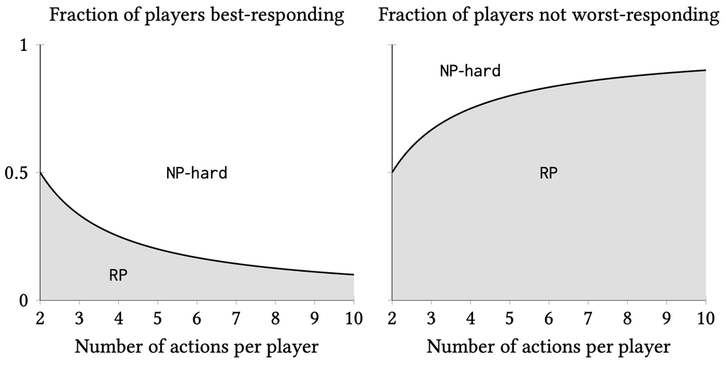

Tractability frontier for best-responding and not worst-responding

# Discussion

## What have we shown?

| Setting | Problem | Complexity |
| --- | --- | --- |
| General games | NWR decision | NP-complete |
| General games | NWR search | NP-hard |
| General games | NWR counting | #P-complete |
| Potential games | NWR search | PLS-complete |
| Partial guarantees | $\alpha$ fraction, top $\beta$ | RP if $\alpha \lesssim \beta$; NP-hard if $\alpha \gtrsim \beta$ |

First four equivalent to their pure Nash equilibrium counterparts.

## The main takeaway

> Computational intractability stems not only from the requirement of **optimality**, but also from the requirement of a **minimal rationality guarantee** for each player.

It’s not about **how well** each player responds.

It’s about requiring **all** players to meet **any** standard simultaneously.

## Open questions

- **Average-case complexity:** Are there natural game distributions where NWR is easy?
- **Mixed strategies:** Does randomisation (mixed actions) help?
- **Dynamics:** Do learning dynamics converge to NWR profiles faster than to NE?

(PLS-completeness implies worst-case exponential convergence, but average case may differ.)

## Thank you!

**Paper:** arxiv.org/abs/2602.10966

**Contact:** edwin.lock@kcl.ac.uk

[figure not shown]